# EDLD651 Final Paper

Author

Frances Pinkham, Eunji Kong, Elyse Calhoun, Yitong Jiang

# Abstract

Environmental factors during childhood, such as parents’ educational level and proximity to a college or university, have been found to impact one’s income. Our current study aims to contribute to existing literature by examining this relationship. Results indicate that parental education is a significant predictor of participants’ education and wages. Additionally, living close to both a four-year university and a community college was correlated with the highest participant income. Examining these factors that impact income is important to understand how to promote equitable opportunity for everyone.

# Introduction

Income level reflects the social and economic advancement in adulthood, and educational attainment has been found to have a direct impact on one’s occupation, income, and wealth.Education is a critical element in the development of individuals and societies, providing a foundation for lifelong learning, personal growth, and social mobility. Among multiple factors that could influence an individual’s educational achievements, parental education has received much attention. Researchers argue that parents’ education may influence parents’ skills, values and knowledge of the educational system; which, in turn, may influence their educational practices at home and the skills children have as models, as well as the parents’ ability to intervene in the educational system on their children’s behalf (Eccles 2005). Parents with more education also have higher expectations for their children’s education, which, in turn, predicts great educational attainment for their children, even until adulthood (Alexander, Entwisle, and Bedinger 1994). Research has shown that young adults whose parents have attained no more than a high school diploma are less likely to aspire to a bachelor’s degree and less likely to be college qualified (Berkner and Chavez 1997; Horn and Nuñez 2000).

Examining predictors and correlates of adult financial well-being and earnings as they relate to one’s upbringing, there are established findings on the links between family background and later occupational outcomes (Deary et al. 2005; Schoon 2010). Given that family economic status is related to the neighborhood that one may live in growing up, one factor that may impact future education attainment may be whether you grew up near a college or university. Card (1995) suggests that growing up in an area near or around a college potentially has a direct effect on wage earnings. The assumption is made that people earn higher wages based on the amount of schooling they have completed (Dearden, Ferri, and Meghir, n.d.). Limited research showed that community of residence (e.g., residence in rural or urban areas, residence near a private or public college) significantly influenced the developments of both males and females’ social and economic standing, including their educational achievements, employment and incomes (Sewell et al. 2003). However, more studies are needed to explore the effects of family background, later educational and occupational outcomes on adult earning ability (Furnham and Cheng 2013).

The purpose of this study is to understand the relationship between parents’ education, geographic locations (i.e., proximity to college), and participants’ education and income. Specifically, given the relationships among these factors in previous literature, we sought to answer:

1. What is the relationship between parent education and participant’s education?
2. What is the relationship between parent education and participant’s wage?
3. Is there a difference in wage depending on whether you lived near a college?

Table 1: Demograpnics

|  | Unique (#) | Missing (%) | Mean | SD | Min | Median | Max |
| --- | --- | --- | --- | --- | --- | --- | --- |
| Participant Education (Yrs) | 11 | 0 | 13.9 | 2.3 | 8.0 | 13.0 | 18.0 |
| Participant Wage (cents/hr) | 659 | 0 | 614.6 | 263.9 | 112.0 | 577.0 | 2404.0 |
| IQ Score | 92 | 0 | 102.4 | 15.4 | 50.0 | 103.0 | 149.0 |
| Age of Participant | 11 | 0 | 28.4 | 3.0 | 24.0 | 28.0 | 34.0 |
| Paternal Education (Yrs) | 20 | 0 | 10.5 | 3.1 | 0.0 | 10.0 | 18.0 |
| Maternal Education (Yrs) | 20 | 0 | 10.8 | 2.8 | 0.0 | 12.0 | 18.0 |

# Method

The current study is a secondary data analysis from the National Longitudinal Survey of Young Men (NLSYM), which started in 1966 with 5525 young men between the ages of 14 and 24 in the United States. The current study looks at a subset of this data collected in 1976.

### Participants

As is true for many longitudinal studies in the mid-1960s (Card 1995), our data is not a random, representative sample of the United States population. Data was collected from neighborhoods with a high concentration of non-White residents. In the 1960s, black represented 10% of the US population (Scammon 1961); however, in our study, 19.73% of our sample were black.

### Measures

In this study, we examined participants’ responses to question regarding their age, ethnicity, IQ score, parent’s education (both maternal and paternal), current level of participant education, participant’s current wage, and proximity to college. The age variable is a continuous variable measured in number of years (*range* = 24- 34), and the ethnicity is a binary categorical variable in which participants were asked whether they identify as black. The IQ score variable is a continuous variable (*range* = 50- 149). Participant and parental education were asked in number of years (continuous variable). Participant current wage was asked as cents earned per hour (*range* = 112- 2404). Lastly, participants were asked whether they live near a 4-year college, community college, both, or neither.

### Statistical Analyses

# Results

Table 2. Model of the relationship between parents' education and participants' education

|  | Model |
| --- | --- |
| (Intercept) | 4.352*** |
|  | [3.834, 4.869] |
| Participants' education | 0.451*** |
|  | [0.414, 0.488] |
| Num.Obs. | 4122 |
| R2 | 0.124 |

+ p < 0.1, * p < 0.05, ** p < 0.01, *** p < 0.001

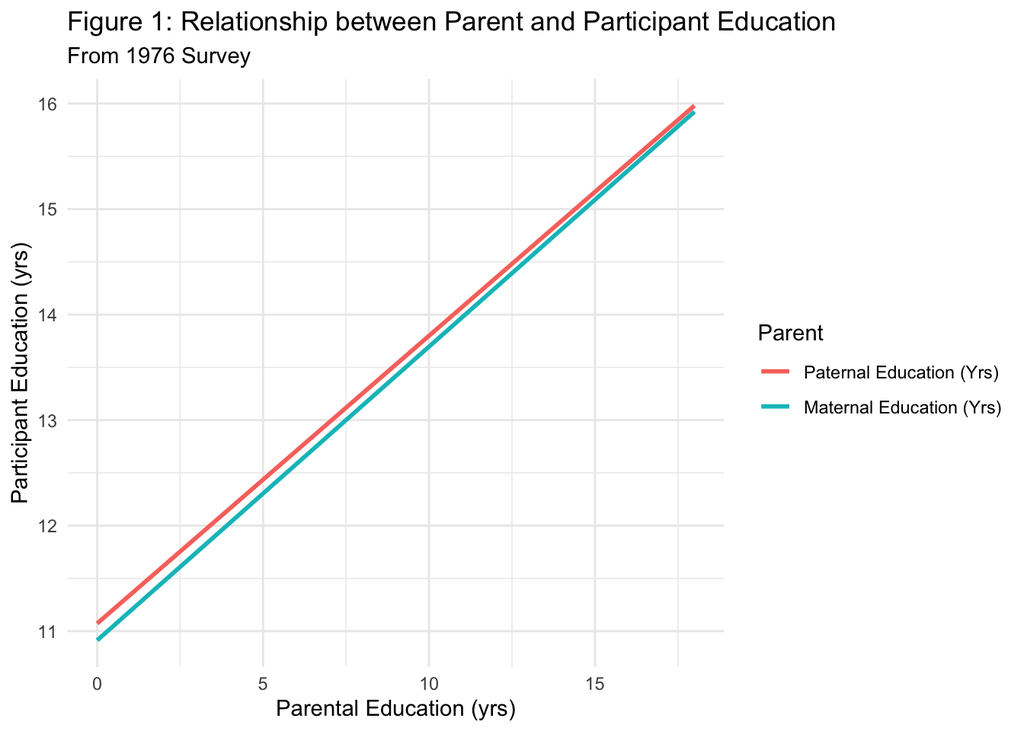

Table 3. Model of the relationship between parents' education and participants' wages

|  | Model |
| --- | --- |
| (Intercept) | 9.853*** |
|  | [9.628, 10.077] |
| Participants' wages | 0.001*** |
|  | [0.001, 0.002] |
| Num.Obs. | 4122 |
| R2 | 0.013 |

+ p < 0.1, * p < 0.05, ** p < 0.01, *** p < 0.001

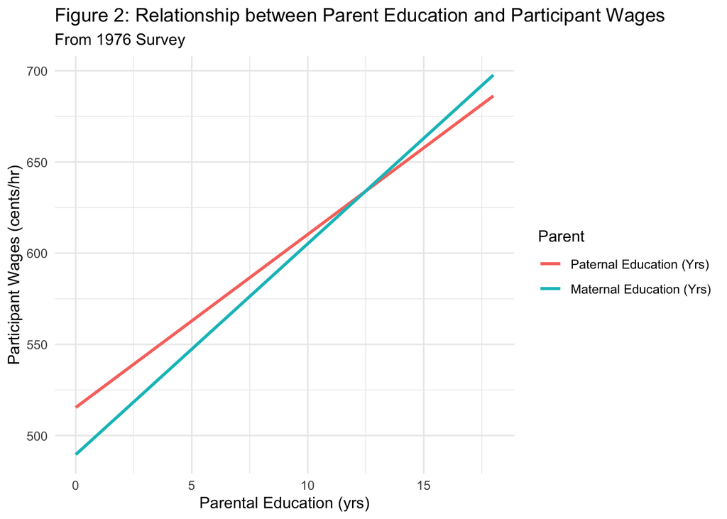

Table 4. Average participant wage based on proximity to college

| Proximity to College | Participant Average Wage per Hour |
| --- | --- |
| Near 4-year College | 6.003385 |
| Near 4-year and Community College | 6.663877 |
| Near Community College | 5.855421 |
| Not Near College | 5.583990 |

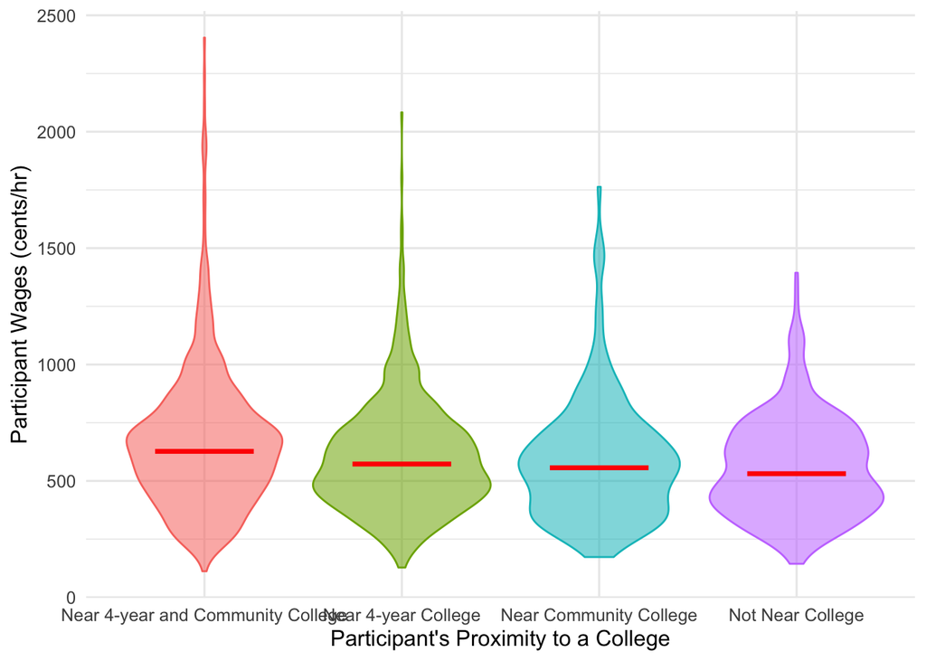

Using ANOVA analysis, we found that there is a statistically significant (p <0.001) relationship between the proximity to college and participant wages. In **Figure 3**, we highlight that there is a meaningful variation in average participant wages both within and between participant’s proximity to a college. Specifically, participants who live near four year and community colleges make higher wages (Mean = 666.39), on average, than other groups. There is substantial variability within each group of proximity to college, with standard deviations in variable participant’s wage (*wage76*) between 213.14 and 300.25.

# Discussion

Family background is believed to have vital influence on individuals’ developments. The current study intended to explain factors that impact young adults’ education length and wages. Our research interest lies in whether young adults from family with longer parental educations and closer residence to college would have different length of education experience and incomes. We chose four factors for discussion, which are parental education, proximity to college, participant education and participant wage.

We created several linear models and tested critical assumptions. After analysis, we found that, on average in the population, a longer parental education is related to longer participant education, and is associated with higher participant wages. Besides, participants who resided near four year and community colleges earn higher wages. Results of both existing studies and research summarized in this paper document the link between family background and offspring’s achievements. We have shown the positive relations of parents’ education as well as family residence (i.e., proximity to the college) to their offspring’s academic and economic achievements. Findings of this study align with those of previous research (e.g., Eccles (2005); Tuijnman, Chinapah, and Fägerlind (1988)).

Yet, there are limitations in our study. We still need to do further explorations and consider more about personal factors and their effects on individuals’ academic and economic gains, such as genders, races, and IQ scores. Also, there is space to analyze the potential covariates among these relations. But still, our study provides a basis for future researchers to examine the impact of family factors and individual developments.

## Reference

Alexander, Karl L, Doris R Entwisle, and Samuel D Bedinger. 1994. “When Expectations Work: Race and Socioeconomic Differences in School Performance.” *Social Psychology Quarterly*, 283–99.

Berkner, Lutz, and Lisa Chavez. 1997. *Access to Postsecondary Education for the 1992 High School Graduates. Postsecondary Education Descriptive Analysis Reports. Statistical Analysis Report.* ERIC.

Card, David. 1995. “Using Geographic Variation in College Proximity to Estimate the Return to Schooling, Aspects of Labour Market Behaviour: Essays in Honour of John Vanderkamp. Ed.” *LN Christofides, EK Grant, and R. Swidinsky*.

Dearden, Lorraine, Javier Ferri, and Costas Meghir. n.d. “THE EFFECT OF SCHOOL QUALITY ON EDUCATIONAL ATTAINMENT AND WAGES.” *THE REVIEW OF ECONOMICS AND STATISTICS*.

Deary, Ian J, Michelle D Taylor, Carole L Hart, Valerie Wilson, George Davey Smith, David Blane, and John M Starr. 2005. “Intergenerational Social Mobility and Mid-Life Status Attainment: Influences of Childhood Intelligence, Childhood Social Factors, and Education.” *Intelligence* 33 (5): 455–72.

Eccles, Jacquelynne S. 2005. “Influences of Parents’ Education on Their Children’s Educational Attainments: The Role of Parent and Child Perceptions.” *London Review of Education*.

Furnham, Adrian, and Helen Cheng. 2013. “Factors Influencing Adult Earnings: Findings from a Nationally Representative Sample.” *The Journal of Socio-Economics* 44: 120–25.

Horn, Laura, and Anne-Marie Nuñez. 2000. *Mapping the Road to College First-Generation Students’ Math Track, Planning Strategies, and Context of Support*. Diane Publishing.

Scammon, Richard. 1961. “1960 Census of the Population: Supplementary Reports: Race of the Population of the United States, by States: 1960.” US Department of Commerce.

Schoon, Ingrid. 2010. “Childhood Cognitive Ability and Adult Academic Attainment: Evidence from Three British Cohort Studies.” *Longitudinal and Life Course Studies* 1 (3): 241–158.

Sewell, William H, Robert M Hauser, Kristen W Springer, and Taissa S Hauser. 2003. “As We Age: A Review of the Wisconsin Longitudinal Study, 1957–2001.” *Research in Social Stratification and Mobility* 20: 3–111.

Tuijnman, Albert, Vinayagum Chinapah, and Ingemar Fägerlind. 1988. “Adult Education and Earnings: A 45-Year Longitudinal Study of 834 Swedish Men.” *Economics of Education Review* 7 (4): 423–37.

Unknown. 2002. “History of Changes to the Minimum Wage Law.” US Department of Labor.